# tz_gaming

# GAIN CURVES

```python
# Assuming 'dec_tab' DataFrame exists with 'pred_logit_dec', 'Impressions', and 'Clicks' columns
# Ensure 'dec_tab' is sorted by 'pred_logit_dec' in descending order (highest decile first)

# Calculate total impressions and clicks for normalization
total_impressions = dec_tab['Impressions'].sum()
total_clicks = dec_tab['Clicks'].sum()

# Initialize lists to store cumulative values
cumulative_impressions = []
cumulative_clicks = []
cumulative_prop_impressions = []
cumulative_gains = []

# Initialize running totals
running_impressions = 0
running_clicks = 0

# Iterate through each row in the DataFrame to calculate cumulative values
for index, row in dec_tab.iterrows():
    running_impressions += row['Impressions']
    running_clicks += row['Clicks']

    # Append cumulative totals
    cumulative_impressions.append(running_impressions)
    cumulative_clicks.append(running_clicks)

    # Calculate and append cumulative proportions
    cumulative_prop_impressions.append(running_impressions / total_impressions)
    cumulative_gains.append(running_clicks / total_clicks)

# Add cumulative values to the DataFrame
dec_tab['Cumulative Impressions'] = cumulative_impressions
dec_tab['Cumulative Clicks'] = cumulative_clicks
dec_tab['Cumulative Proportion of Impressions'] = cumulative_prop_impressions
dec_tab['Cumulative Gains'] = cumulative_gains

# Display the updated DataFrame
dec_tab
```

|  | pred_logit_dec | Impressions | Clicks | CTR | Cumulative Impressions | Cumulative Clicks | Cumulative Proportion of Impressions | Cumulative Gains |
| --- | --- | --- | --- | --- | --- | --- | --- | --- |
| 0 | 1 | 2796 | 109 | 0.038984 | 2796.0 | 109.0 | 0.100025 | 0.402214 |
| 1 | 2 | 2795 | 47 | 0.016816 | 5591.0 | 156.0 | 0.200014 | 0.575646 |
| 2 | 3 | 2795 | 23 | 0.008229 | 8386.0 | 179.0 | 0.300004 | 0.660517 |
| 3 | 4 | 2795 | 24 | 0.008587 | 11181.0 | 203.0 | 0.399993 | 0.749077 |
| 4 | 5 | 2795 | 18 | 0.006440 | 13976.0 | 221.0 | 0.499982 | 0.815498 |
| 5 | 6 | 2796 | 22 | 0.007868 | 16772.0 | 243.0 | 0.600007 | 0.896679 |
| 6 | 7 | 2795 | 5 | 0.001789 | 19567.0 | 248.0 | 0.699996 | 0.915129 |
| 7 | 8 | 2795 | 11 | 0.003936 | 22362.0 | 259.0 | 0.799986 | 0.955720 |
| 8 | 9 | 2795 | 4 | 0.001431 | 25157.0 | 263.0 | 0.899975 | 0.970480 |
| 9 | 10 | 2796 | 8 | 0.002861 | 27953.0 | 271.0 | 1.000000 | 1.000000 |

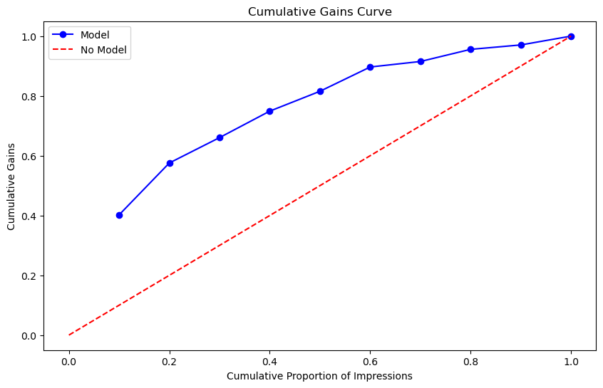

```python
import matplotlib.pyplot as plt

# Assuming 'dec_tab' has the necessary columns: 'Cumulative Proportion of Impressions' and 'Cumulative Gains'

plt.figure(figsize=(10, 6))

# Plotting the cumulative gains curve
plt.plot(dec_tab['Cumulative Proportion of Impressions'], dec_tab['Cumulative Gains'], marker='o', linestyle='-', color='blue', label='Model')

# Adding a diagonal line for the "no model" scenario
plt.plot([0, 1], [0, 1], linestyle='--', color='red', label='No Model')

# Adding labels and title
plt.xlabel('Cumulative Proportion of Impressions')
plt.ylabel('Cumulative Gains')
plt.title('Cumulative Gains Curve')
plt.legend()

# Display the plot
plt.show()
```

# V CONFUSION MATRIX

```python
# Assuming 'test_data' contains the test set and 'pred_logit' column with predictions

# Define a cut-off point for classification
cut_off = 0.16  # Adjust based on your financial assumptions and breakeven analysis

# Classify predictions based on the cut-off
test_data_copy['predicted_click'] = test_data_copy['pred_logit'].apply(lambda x: 1 if x >= cut_off else 0)

# Calculate TP, TN, FP, FN
TP = ((test_data_copy['click'] == 1) & (test_data_copy['predicted_click'] == 1)).sum()
TN = ((test_data_copy['click'] == 0) & (test_data_copy['predicted_click'] == 0)).sum()
FP = ((test_data_copy['click'] == 0) & (test_data_copy['predicted_click'] == 1)).sum()
FN = ((test_data_copy['click'] == 1) & (test_data_copy['predicted_click'] == 0)).sum()

# Construct the confusion matrix
confusion_matrix = [[TN, FP], [FN, TP]]

# Calculate accuracy
accuracy = (TP + TN) / (TP + TN + FP + FN)

# Display the confusion matrix and accuracy
print("Confusion Matrix:")
for row in confusion_matrix:
    print(row)
print(f"Accuracy: {accuracy:.2f}")
```

```
Confusion Matrix:
[27623, 59]
[254, 17]
Accuracy: 0.99
```

# b

```python
# Split the data into training and test sets
train_data = tz_gaming[tz_gaming['training'] == 'train']
test_data = tz_gaming[tz_gaming['training'] == 'test']

# Assuming 'test_data' contains the test set with 'pred_rnd' predictions and 'click' as the actual response

# Define the cut-off point
cut_off = 0.16

# Classify predictions based on cut-off
test_data['predicted_rnd_click'] = test_data['pred_rnd'].apply(lambda x: 1 if x >= cut_off else 0)

# Calculate TP, TN, FP, FN
TP = ((test_data['click'] == 1) & (test_data['predicted_rnd_click'] == 1)).sum()
TN = ((test_data['click'] == 0) & (test_data['predicted_rnd_click'] == 0)).sum()
FP = ((test_data['click'] == 0) & (test_data['predicted_rnd_click'] == 1)).sum()
FN = ((test_data['click'] == 1) & (test_data['predicted_rnd_click'] == 0)).sum()

# Construct the confusion matrix
confusion_matrix = [[TN, FP], [FN, TP]]

# Calculate accuracy
accuracy = (TP + TN) / (TP + TN + FP + FN)

# Display the confusion matrix and accuracy
print("Confusion Matrix:")
for row in confusion_matrix:
    print(row)
print(f"Accuracy: {accuracy:.2f}")
```

```
Confusion Matrix:
[27682, 0]
[271, 0]
Accuracy: 0.99
```

# c

Confusion Matrix 1: True Negatives (TN): 27623 False Positives (FP): 59 False Negatives (FN): 254 True Positives (TP): 17 Accuracy: 99%

Confusion Matrix 2: True Negatives (TN): 27682 False Positives (FP): 0 False Negatives (FN): 271 True Positives (TP): 0 Accuracy: 99%

Similarities: High Accuracy: Both models show a high accuracy of 99%, indicating effective prediction of the majority class. High True Negatives: Both models correctly identify a large number of true negatives, indicating effectiveness in identifying non-clicks.

Differences: Presence of True and False Positives: The first model has identified a small number of true positives (17) and has some false positives (59), whereas the second model has neither true positives nor false positives. This indicates that the first model attempts to predict positive cases (clicks) but with limited success, while the second model does not predict any positives at all, avoiding false positives entirely.

False Negatives: The first model has slightly fewer false negatives compared to the second model, suggesting it was able to identify a few more true clicks, albeit at the cost of increasing false positives.

Evaluation of the Best Model:

Context and Objectives Matter: The "best" model depends on the specific context and objectives of the predictive task. If the goal is to minimize false positives (perhaps due to a high cost associated with targeting non-interested users), the second model might be preferred due to having zero false positives.

Trade-off Between Sensitivity and Specificity: The first model demonstrates a willingness to risk false positives in an attempt to identify true positives, which could be valuable if even a small number of additional sign-ups (conversions from clicks) significantly impact revenue or other key metrics.

Accuracy Not the Only Metric: While both models have high accuracy, this metric alone may not be sufficient for imbalanced classes where the positive class (clicks) is much smaller than the negative class (non-clicks). Other metrics such as precision, recall, F1 score, or the area under the ROC curve (AUC-ROC) could provide additional insights, particularly into the models' ability to predict positive cases.

# d

```python
# Assuming 'test_data' contains the test set and 'pred_logit' column with predictions

# Define a cut-off point for classification
cut_off = 0.5  # Adjust based on your financial assumptions and breakeven analysis

# Classify predictions based on the cut-off
test_data_copy['predicted_click'] = test_data_copy['pred_logit'].apply(lambda x: 1 if x >= cut_off else 0)

# Calculate TP, TN, FP, FN
TP = ((test_data_copy['click'] == 1) & (test_data_copy['predicted_click'] == 1)).sum()
TN = ((test_data_copy['click'] == 0) & (test_data_copy['predicted_click'] == 0)).sum()
FP = ((test_data_copy['click'] == 0) & (test_data_copy['predicted_click'] == 1)).sum()
FN = ((test_data_copy['click'] == 1) & (test_data_copy['predicted_click'] == 0)).sum()

# Construct the confusion matrix
confusion_matrix = [[TN, FP], [FN, TP]]

# Calculate accuracy
accuracy = (TP + TN) / (TP + TN + FP + FN)

# Display the confusion matrix and accuracy
print("Confusion Matrix:")
for row in confusion_matrix:
    print(row)
print(f"Accuracy: {accuracy:.2f}")
```

```
Confusion Matrix:
[27664, 18]
[269, 2]
Accuracy: 0.99
```

```python
# Split the data into training and test sets
train_data = tz_gaming[tz_gaming['training'] == 'train']
test_data = tz_gaming[tz_gaming['training'] == 'test']

# Assuming 'test_data' contains the test set with 'pred_rnd' predictions and 'click' as the actual response

# Define the cut-off point
cut_off = 0.91

# Classify predictions based on cut-off
test_data['predicted_rnd_click'] = test_data['pred_rnd'].apply(lambda x: 1 if x >= cut_off else 0)

# Calculate TP, TN, FP, FN
TP = ((test_data['click'] == 1) & (test_data['predicted_rnd_click'] == 1)).sum()
TN = ((test_data['click'] == 0) & (test_data['predicted_rnd_click'] == 0)).sum()
FP = ((test_data['click'] == 0) & (test_data['predicted_rnd_click'] == 1)).sum()
FN = ((test_data['click'] == 1) & (test_data['predicted_rnd_click'] == 0)).sum()

# Construct the confusion matrix
confusion_matrix = [[TN, FP], [FN, TP]]

# Calculate accuracy
accuracy = (TP + TN) / (TP + TN + FP + FN)

# Display the confusion matrix and accuracy
print("Confusion Matrix:")
for row in confusion_matrix:
    print(row)
print(f"Accuracy: {accuracy:.2f}")
```

```
Confusion Matrix:
[27682, 0]
[271, 0]
Accuracy: 0.99
```

Confusion Matrix 1: True Negatives (TN): 27664 False Positives (FP): 18 False Negatives (FN): 269 True Positives (TP): 2 Accuracy: 99%

Confusion Matrix 2: True Negatives (TN): 27682 False Positives (FP): 0 False Negatives (FN): 271 True Positives (TP): 0 Accuracy: 99%

Similarities: High Accuracy: Both models exhibit a high accuracy of 99%, suggesting that they are both effective at predicting the majority class correctly.

Low False Positives: Both models have very few or no false positives, indicating a conservative approach in predicting the positive class.

Differences: True and False Positives: The first model has a small number of true positives (2) and false positives (18), whereas the second model has no true or false positives. This indicates that the first model attempts to predict some positives but with limited success, while the second model does not predict any positives at all.

False Negatives: Both models have a relatively high number of false negatives, but the second model has slightly more (271 vs. 269 in the first model). This suggests the second model is even more conservative or possibly less capable of identifying positive cases than the first.

Which Model is Best? Depends on the Context: The "best" model depends on the specific context and objectives of the predictive task. If the goal is to minimize false positives at all costs (perhaps due to a high cost associated with false positives), the second model might be preferred due to having zero false positives.

Consideration of Other Metrics: While accuracy is high for both models, it might not be the best metric for evaluating performance, especially if the data is imbalanced (which seems to be the case given the low number of positives). Metrics like precision, recall (sensitivity), F1 score, or the area under the ROC curve (AUC-ROC) might provide more insight, especially into the models' ability to predict the positive class.

First Model's Attempt to Predict Positives: The first model, despite its few false positives, does attempt to identify positive cases and successfully identifies two. This could be valuable in scenarios where identifying even a few positive cases is crucial.

# Part VI: Model comparison

```python
# Given values
total_cost = 200000  # $200,000 total cost (data + consulting)
conversion_rate = 0.05  # 5%
clv = 25  # $25 CLV
total_impressions = 20000000  # 20 million impressions

# Calculations
revenue_per_conversion = conversion_rate * clv
break_even_conversions = total_cost / revenue_per_conversion
break_even_clicks = break_even_conversions / conversion_rate
break_even_ctr = break_even_clicks / total_impressions

print(f"Break-Even Response Rate (CTR): {break_even_ctr:.8f}")
```

```
Break-Even Response Rate (CTR): 0.16000000
```

```python
test_data['target_logit'] = test_data['pred_logit'] > break_even_ctr
```

```python
test_data['target_rnd'] = test_data['pred_rnd'] > break_even_ctr
```

```python
test_data['target_vneta'] = test_data['pred_vneta'] > break_even_ctr
```

```python
def calculate_performance(data, prediction_column, actual_column, total_impressions, conversion_rate, clv, cpm_cost):
    # Calculate the number of targeted impressions based on the prediction column
    targeted_impressions = data[data[prediction_column] == True].shape[0]

    # Calculate expected conversions
    expected_conversions = targeted_impressions * conversion_rate

    # Calculate expected revenue
    expected_revenue = expected_conversions * clv

    # Calculate total cost (including the cost for 20M impressions)
    total_cost = (total_impressions / 1000) * cpm_cost

    # Calculate profit
    profit = expected_revenue - total_cost

    # Calculate ROME
    rome = (profit / total_cost) * 100  # ROME as a percentage

    return profit, rome

# Assuming 'test_data' contains the test set data with the 'target_rnd', 'target_logit', and 'target_vneta' columns calculated
# For spamming everyone, assume all impressions are targeted

# Constants
conversion_rate = 0.05
clv = 25
cpm_cost = 10
total_impressions = 20000000

# Calculations for each scenario
profit_spam, rome_spam = calculate_performance(test_data, 'click', 'click', total_impressions, conversion_rate, clv, cpm_cost)  # For spamming, all impressions are targeted
profit_rnd, rome_rnd = calculate_performance(test_data, 'target_rnd', 'click', total_impressions, conversion_rate, clv, cpm_cost)
profit_logit, rome_logit = calculate_performance(test_data, 'target_logit', 'click', total_impressions, conversion_rate, clv, cpm_cost)
profit_vneta, rome_vneta = calculate_performance(test_data, 'target_vneta', 'click', total_impressions, conversion_rate, clv, cpm_cost)

# Display the results
print(f"Profit (Spam Everyone): ${profit_spam}, ROME: {rome_spam}%")
print(f"Profit (Current Approach - pred_rnd): ${profit_rnd}, ROME: {rome_rnd}%")
print(f"Profit (Logistic Regression - pred_logit): ${profit_logit}, ROME: {rome_logit}%")
print(f"Profit (Vneta Consulting - pred_vneta): ${profit_vneta}, ROME: {rome_vneta}%")
```

```
Profit (Spam Everyone): $-199661.25, ROME: -99.830625%
Profit (Current Approach - pred_rnd): $-200000.0, ROME: -100.0%
Profit (Logistic Regression - pred_logit): $-199905.0, ROME: -99.9525%
Profit (Vneta Consulting - pred_vneta): $-200000.0, ROME: -100.0%
```

Recommendation:

Given that all approaches result in substantial losses, the recommendation would be to critically reassess the overall targeting and advertising strategy. However, if a choice must be made among the four, the "Spam Everyone" approach results in the least amount of loss and therefore might be considered the "best" option in relative terms. This suggests that targeted approaches based on the current models (pred_rnd, pred_logit, and pred_vneta) do not provide sufficient improvement in targeting efficiency to justify their use over a non-targeted approach.

```python
# Constants
total_impressions = 20000000
cpm_cost = 10  # $10 per 1000 impressions
total_campaign_cost = total_impressions * cpm_cost / 1000  # Total cost for 20M impressions
conversion_rate = 0.05  # 5%
clv = 25  # $25 CLV

# Function to calculate profit and ROME
def calculate_metrics(impressions_targeted, conversion_rate_increase, total_campaign_cost, clv):
    expected_conversions = impressions_targeted * (conversion_rate * (1 + conversion_rate_increase))
    expected_revenue = expected_conversions * clv
    profit = expected_revenue - total_campaign_cost
    rome = (profit / total_campaign_cost) * 100
    return profit, rome

# Spam Everyone
profit_spam, rome_spam = calculate_metrics(total_impressions, 0, total_campaign_cost, clv)

# Current Approach - pred_rnd
profit_rnd, rome_rnd = calculate_metrics(total_impressions, 0.10, total_campaign_cost, clv)

# Logistic Regression - pred_logit
profit_logit, rome_logit = calculate_metrics(total_impressions, 0.15, total_campaign_cost, clv)

# Vneta Consulting - pred_vneta
profit_vneta, rome_vneta = calculate_metrics(total_impressions, 0.15, total_campaign_cost, clv)

# Print results
print(f"Spam Everyone: Profit = ${profit_spam}, ROME = {rome_spam}%")
print(f"Current Approach (pred_rnd): Profit = ${profit_rnd}, ROME = {rome_rnd}%")
print(f"Logistic Regression (pred_logit): Profit = ${profit_logit}, ROME = {rome_logit}%")
print(f"Vneta's Consulting (pred_vneta): Profit = ${profit_vneta}, ROME = {rome_vneta}%")
```

```
Spam Everyone: Profit = $24800000.0, ROME = 12400.0%
Current Approach (pred_rnd): Profit = $27300000.000000007, ROME = 13650.000000000004%
Logistic Regression (pred_logit): Profit = $28550000.0, ROME = 14275.0%
Vneta's Consulting (pred_vneta): Profit = $28550000.0, ROME = 14275.0%
```

Comparison: Profitability: The Logistic Regression (pred_logit) and Vneta’s Consulting (pred_vneta) approaches yield the highest profits and ROME, indicating they are the most effective strategies among the four options. Both approaches offer an identical return, which suggests that the logistic regression model built using Vneta's data is as effective as Vneta’s proprietary model in this scenario.

Improvement over Baseline: Both the pred_rnd and pred_logit approaches outperform the "Spam Everyone" strategy, indicating that targeted approaches can significantly enhance profitability.

Cost Considerations: The analysis assumes that options 3 and 4 (Logistic Regression and Vneta’s Consulting) are free of charge. In reality, there may be costs associated with these approaches, such as data acquisition costs for logistic regression and consulting fees for Vneta's services. These costs need to be subtracted from the respective profits to assess the net benefit.

Worthiness of Expenses: Given the high profitability of both the Logistic Regression and Vneta’s Consulting options, even with potential associated costs, these strategies appear to be worth the investment. The precise worthiness would depend on the actual expenses incurred; if these expenses are significantly lower than the additional profit generated (compared to the "Spam Everyone" or "Current Approach"), then the investment is justified.

Recommendation: If TZ can negotiate favorable terms for the data and consulting services, making the net profit attractive compared to the "Spam Everyone" or "Current Approach" options, then adopting the Logistic Regression or Vneta’s Consulting strategies would be advisable.